# Neural_Project

### Neural Network with Balanced Data (by applying SMOTE) and SGD Optimizer

```
After UpSampling, the shape of train_X: (9554, 11)
After UpSampling, the shape of train_y: (9554,)

Model: "sequential"
_________________________________________________________________
 Layer (type)                Output Shape              Param #
=================================================================
 dense (Dense)               (None, 64)                768

 dense_1 (Dense)             (None, 32)                2080

 dense_2 (Dense)             (None, 16)                528

 dense_3 (Dense)             (None, 1)                 17

=================================================================
Total params: 3393 (13.25 KB)
Trainable params: 3393 (13.25 KB)
Non-trainable params: 0 (0.00 Byte)
_________________________________________________________________
```

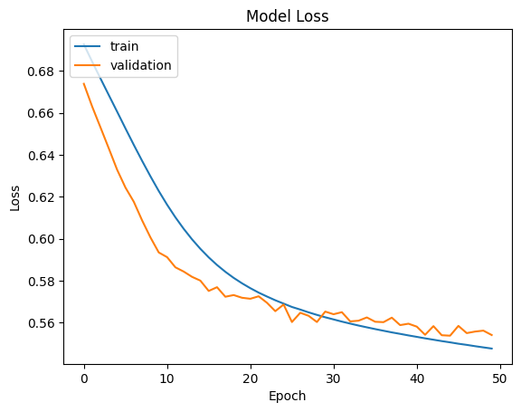

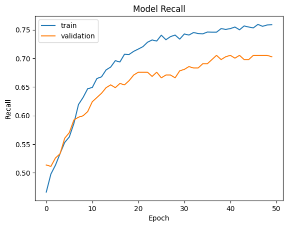

```
              precision    recall  f1-score   support

           0       0.75      0.71      0.73      4777
           1       0.72      0.76      0.74      4777

    accuracy                           0.74      9554
   macro avg       0.74      0.74      0.73      9554
weighted avg       0.74      0.74      0.73      9554

              precision    recall  f1-score   support

           0       0.90      0.72      0.80      1593
           1       0.39      0.70      0.50       407

    accuracy                           0.71      2000
   macro avg       0.65      0.71      0.65      2000
weighted avg       0.80      0.71      0.74      2000
```

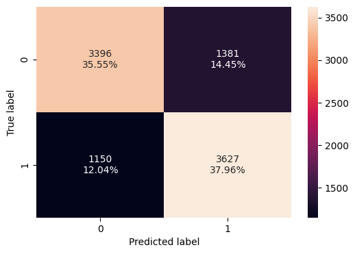

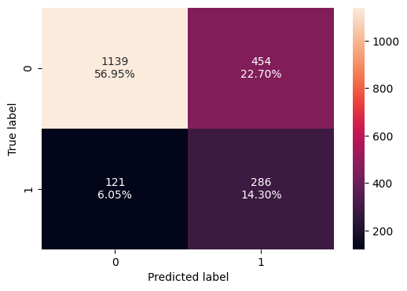

```python
# Import necessary libraries
import tensorflow as tf
from tensorflow.keras.models import Sequential
from tensorflow.keras.layers import Dense
from tensorflow.keras.optimizers import SGD
from sklearn.metrics import recall_score, classification_report
from imblearn.over_sampling import SMOTE
import numpy as np
import matplotlib.pyplot as plt
import seaborn as sns

# Apply SMOTE to balance the dataset
sm = SMOTE(random_state=42)
X_train_smote, y_train_smote = sm.fit_resample(X_train, y_train)
print('After UpSampling, the shape of train_X: {}'.format(X_train_smote.shape))
print('After UpSampling, the shape of train_y: {} \n'.format(y_train_smote.shape))

# Build a model with the balanced dataset
tf.keras.backend.clear_session()
np.random.seed(2)
tf.random.set_seed(2)

# Initializing the model
model_3 = Sequential()

# Adding the input layer with 64 neurons and relu as activation function
model_3.add(Dense(64, activation='relu', input_dim=X_train_smote.shape[1]))

# Adding a hidden layer with 32 neurons and relu as activation function
model_3.add(Dense(32, activation='relu'))

# Adding another hidden layer with 16 neurons and relu as activation function
model_3.add(Dense(16, activation='relu'))

# Adding the output layer with 1 neuron and sigmoid as activation function
model_3.add(Dense(1, activation='sigmoid'))

# Using SGD as the optimizer
optimizer = tf.keras.optimizers.SGD(0.001)

# Using recall as the metric
metric = tf.keras.metrics.Recall()

# Compiling the model with binary cross entropy as the loss function and recall as the metric
model_3.compile(loss='binary_crossentropy', optimizer=optimizer, metrics=[metric])

# Displaying the model summary
model_3.summary()

# Fitting the ANN
history_3 = model_3.fit(
    X_train_smote, y_train_smote,
    batch_size=32,  # specify the batch size
    validation_data=(X_val, y_val),
    epochs=50,  # specify the number of epochs
    verbose=1
)

# Plotting Train Loss vs Validation Loss
plt.plot(history_3.history['loss'])
plt.plot(history_3.history['val_loss'])
plt.title('Model Loss')
plt.ylabel('Loss')
plt.xlabel('Epoch')
plt.legend(['train', 'validation'], loc='upper left')
plt.show()

# Plotting Train Recall vs Validation Recall
plt.plot(history_3.history['recall'])
plt.plot(history_3.history['val_recall'])
plt.title('Model Recall')
plt.ylabel('Recall')
plt.xlabel('Epoch')
plt.legend(['train', 'validation'], loc='upper left')
plt.show()

# Predicting the results using 0.5 as the threshold
y_train_pred = model_3.predict(X_train_smote)
y_train_pred = (y_train_pred > 0.5).astype(int)

# Predicting the results on the validation set using 0.5 as the threshold
y_val_pred = model_3.predict(X_val)
y_val_pred = (y_val_pred > 0.5).astype(int)

# Storing recall scores for the model
model_name = "NN with SMOTE & SGD"
train_metric_df.loc[model_name] = recall_score(y_train_smote, y_train_pred)
valid_metric_df.loc[model_name] = recall_score(y_val, y_val_pred)

# Displaying classification report for the training set
cr = classification_report(y_train_smote, y_train_pred)
print(cr)

# Displaying classification report for the validation set
cr = classification_report(y_val, y_val_pred)
print(cr)

# Plotting confusion matrix for the training set
make_confusion_matrix(y_train_smote, y_train_pred)

# Plotting confusion matrix for the validation set
make_confusion_matrix(y_val, y_val_pred)
```

### Neural Network with Balanced Data (by applying SMOTE) and Adam Optimizer

```
After UpSampling, the shape of train_X: (9554, 11)
After UpSampling, the shape of train_y: (9554,)

Model: "sequential"
_________________________________________________________________
 Layer (type)                Output Shape              Param #
=================================================================
 dense (Dense)               (None, 64)                768

 dense_1 (Dense)             (None, 32)                2080

 dense_2 (Dense)             (None, 16)                528

 dense_3 (Dense)             (None, 1)                 17

=================================================================
Total params: 3393 (13.25 KB)
Trainable params: 3393 (13.25 KB)
Non-trainable params: 0 (0.00 Byte)
_________________________________________________________________
```

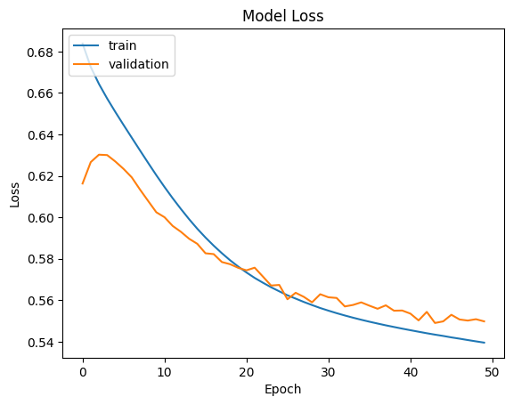

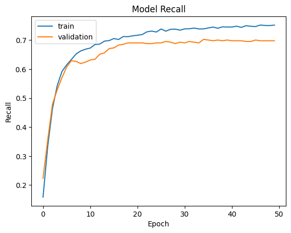

```
              precision    recall  f1-score   support

           0       0.74      0.70      0.72      4777
           1       0.72      0.75      0.73      4777

    accuracy                           0.73      9554
   macro avg       0.73      0.73      0.73      9554
weighted avg       0.73      0.73      0.73      9554

              precision    recall  f1-score   support

           0       0.90      0.71      0.80      1593
           1       0.38      0.70      0.50       407

    accuracy                           0.71      2000
   macro avg       0.64      0.71      0.65      2000
weighted avg       0.80      0.71      0.74      2000
```

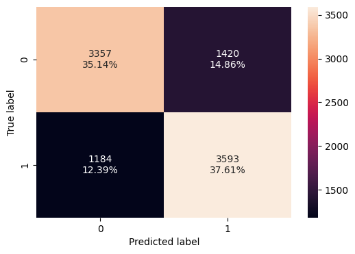

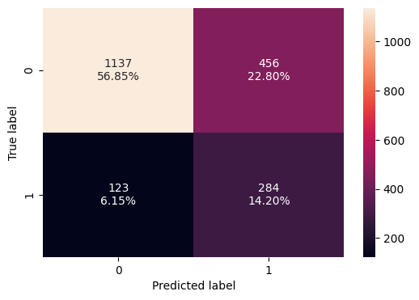

```
Model: "sequential"
_________________________________________________________________
 Layer (type)                Output Shape              Param #
=================================================================
 dense (Dense)               (None, 64)                768

 dense_1 (Dense)             (None, 32)                2080

 dense_2 (Dense)             (None, 16)                528

 dense_3 (Dense)             (None, 1)                 17

=================================================================
Total params: 3393 (13.25 KB)
Trainable params: 3393 (13.25 KB)
Non-trainable params: 0 (0.00 Byte)
_________________________________________________________________
```

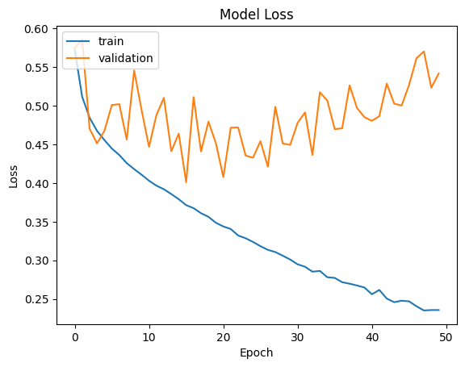

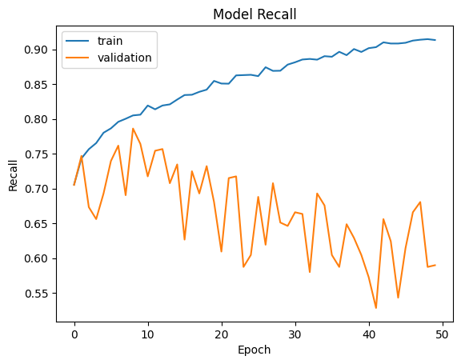

```
              precision    recall  f1-score   support

           0       0.90      0.92      0.91      4777
           1       0.92      0.90      0.91      4777

    accuracy                           0.91      9554
   macro avg       0.91      0.91      0.91      9554
weighted avg       0.91      0.91      0.91      9554

              precision    recall  f1-score   support

           0       0.89      0.87      0.88      1593
           1       0.54      0.59      0.57       407

    accuracy                           0.82      2000
   macro avg       0.72      0.73      0.72      2000
weighted avg       0.82      0.82      0.82      2000
```

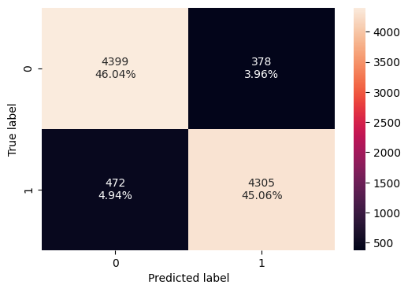

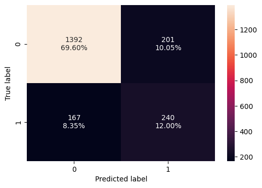

```python
# Import necessary libraries
import tensorflow as tf
from tensorflow.keras.models import Sequential
from tensorflow.keras.layers import Dense, Dropout
from tensorflow.keras.optimizers import SGD, Adam
from sklearn.metrics import recall_score, classification_report
from imblearn.over_sampling import SMOTE
import numpy as np
import matplotlib.pyplot as plt
import seaborn as sns

# Apply SMOTE to balance the dataset
sm = SMOTE(random_state=42)
X_train_smote, y_train_smote = sm.fit_resample(X_train, y_train)
print('After UpSampling, the shape of train_X: {}'.format(X_train_smote.shape))
print('After UpSampling, the shape of train_y: {} \n'.format(y_train_smote.shape))

# Building a model with SMOTE and SGD optimizer

# Clear previous models
tf.keras.backend.clear_session()
np.random.seed(2)
tf.random.set_seed(2)

# Initializing the model
model_3 = Sequential()

# Adding the input layer with 64 neurons and relu as activation function
model_3.add(Dense(64, activation='relu', input_dim=X_train_smote.shape[1]))

# Adding a hidden layer with 32 neurons and relu as activation function
model_3.add(Dense(32, activation='relu'))

# Adding another hidden layer with 16 neurons and relu as activation function
model_3.add(Dense(16, activation='relu'))

# Adding the output layer with 1 neuron and sigmoid as activation function
model_3.add(Dense(1, activation='sigmoid'))

# Using SGD as the optimizer
optimizer = SGD(0.001)

# Using recall as the metric
metric = tf.keras.metrics.Recall()

# Compiling the model with binary cross entropy as the loss function and recall as the metric
model_3.compile(loss='binary_crossentropy', optimizer=optimizer, metrics=[metric])

# Displaying the model summary
model_3.summary()

# Fitting the ANN
history_3 = model_3.fit(
    X_train_smote, y_train_smote,
    batch_size=32,  # specify the batch size
    validation_data=(X_val, y_val),
    epochs=50,  # specify the number of epochs
    verbose=1
)

# Plotting Train Loss vs Validation Loss
plt.plot(history_3.history['loss'])
plt.plot(history_3.history['val_loss'])
plt.title('Model Loss')
plt.ylabel('Loss')
plt.xlabel('Epoch')
plt.legend(['train', 'validation'], loc='upper left')
plt.show()

# Plotting Train Recall vs Validation Recall
plt.plot(history_3.history['recall'])
plt.plot(history_3.history['val_recall'])
plt.title('Model Recall')
plt.ylabel('Recall')
plt.xlabel('Epoch')
plt.legend(['train', 'validation'], loc='upper left')
plt.show()

# Predicting the results using 0.5 as the threshold
y_train_pred = model_3.predict(X_train_smote)
y_train_pred = (y_train_pred > 0.5).astype(int)

# Predicting the results on the validation set using 0.5 as the threshold
y_val_pred = model_3.predict(X_val)
y_val_pred = (y_val_pred > 0.5).astype(int)

# Storing recall scores for the model
model_name = "NN with SMOTE & SGD"
train_metric_df.loc[model_name] = recall_score(y_train_smote, y_train_pred)
valid_metric_df.loc[model_name] = recall_score(y_val, y_val_pred)

# Displaying classification report for the training set
cr = classification_report(y_train_smote, y_train_pred)
print(cr)

# Displaying classification report for the validation set
cr = classification_report(y_val, y_val_pred)
print(cr)

# Plotting confusion matrix for the training set
make_confusion_matrix(y_train_smote, y_train_pred)

# Plotting confusion matrix for the validation set
make_confusion_matrix(y_val, y_val_pred)

# Building a model with SMOTE and Adam optimizer

# Clear previous models
tf.keras.backend.clear_session()
np.random.seed(2)
tf.random.set_seed(2)

# Initializing the model
model_4 = Sequential()

# Adding the input layer with 64 neurons and relu as activation function
model_4.add(Dense(64, activation='relu', input_dim=X_train_smote.shape[1]))

# Adding a hidden layer with 32 neurons and relu as activation function
model_4.add(Dense(32, activation='relu'))

# Adding another hidden layer with 16 neurons and relu as activation function
model_4.add(Dense(16, activation='relu'))

# Adding the output layer with 1 neuron and sigmoid as activation function
model_4.add(Dense(1, activation='sigmoid'))

# Using Adam as the optimizer
optimizer = Adam()

# Using recall as the metric
metric = tf.keras.metrics.Recall()

# Compiling the model with binary cross entropy as the loss function and recall as the metric
model_4.compile(loss='binary_crossentropy', optimizer=optimizer, metrics=[metric])

# Displaying the model summary
model_4.summary()

# Fitting the ANN
history_4 = model_4.fit(
    X_train_smote, y_train_smote,
    batch_size=32,  # specify the batch size
    validation_data=(X_val, y_val),
    epochs=50,  # specify the number of epochs
    verbose=1
)

# Plotting Train Loss vs Validation Loss
plt.plot(history_4.history['loss'])
plt.plot(history_4.history['val_loss'])
plt.title('Model Loss')
plt.ylabel('Loss')
plt.xlabel('Epoch')
plt.legend(['train', 'validation'], loc='upper left')
plt.show()

# Plotting Train Recall vs Validation Recall
plt.plot(history_4.history['recall'])
plt.plot(history_4.history['val_recall'])
plt.title('Model Recall')
plt.ylabel('Recall')
plt.xlabel('Epoch')
plt.legend(['train', 'validation'], loc='upper left')
plt.show()

# Predicting the results using 0.5 as the threshold
y_train_pred = model_4.predict(X_train_smote)
y_train_pred = (y_train_pred > 0.5).astype(int)

# Predicting the results on the validation set using 0.5 as the threshold
y_val_pred = model_4.predict(X_val)
y_val_pred = (y_val_pred > 0.5).astype(int)

# Storing recall scores for the model
model_name = "NN with SMOTE & Adam"
train_metric_df.loc[model_name] = recall_score(y_train_smote, y_train_pred)
valid_metric_df.loc[model_name] = recall_score(y_val, y_val_pred)

# Displaying classification report for the training set
cr = classification_report(y_train_smote, y_train_pred)
print(cr)

# Displaying classification report for the validation set
cr = classification_report(y_val, y_val_pred)
print(cr)

# Plotting confusion matrix for the training set
make_confusion_matrix(y_train_smote, y_train_pred)

# Plotting confusion matrix for the validation set
make_confusion_matrix(y_val, y_val_pred)
```

### Neural Network with Balanced Data (by applying SMOTE), Adam Optimizer, and Dropout

```
After UpSampling, the shape of train_X: (9554, 11)
After UpSampling, the shape of train_y: (9554,)

Model: "sequential"
_________________________________________________________________
 Layer (type)                Output Shape              Param #
=================================================================
 dense (Dense)               (None, 64)                768

 dense_1 (Dense)             (None, 32)                2080

 dense_2 (Dense)             (None, 16)                528

 dense_3 (Dense)             (None, 1)                 17

=================================================================
Total params: 3393 (13.25 KB)
Trainable params: 3393 (13.25 KB)
Non-trainable params: 0 (0.00 Byte)
_________________________________________________________________
```

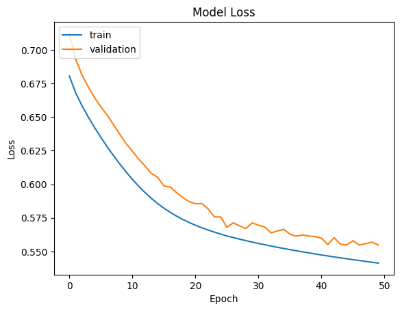

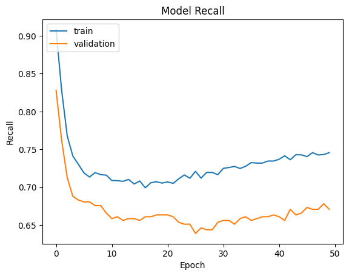

```
              precision    recall  f1-score   support

           0       0.74      0.73      0.73      4777
           1       0.73      0.75      0.74      4777

    accuracy                           0.74      9554
   macro avg       0.74      0.74      0.74      9554
weighted avg       0.74      0.74      0.74      9554

              precision    recall  f1-score   support

           0       0.90      0.73      0.80      1593
           1       0.39      0.67      0.49       407

    accuracy                           0.72      2000
   macro avg       0.64      0.70      0.65      2000
weighted avg       0.79      0.72      0.74      2000
```

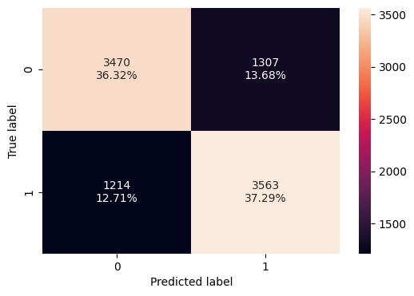

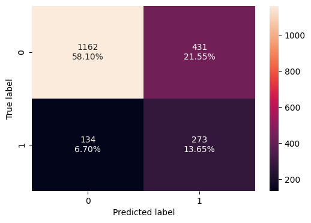

```
Model: "sequential"
_________________________________________________________________
 Layer (type)                Output Shape              Param #
=================================================================
 dense (Dense)               (None, 64)                768

 dense_1 (Dense)             (None, 32)                2080

 dense_2 (Dense)             (None, 16)                528

 dense_3 (Dense)             (None, 1)                 17

=================================================================
Total params: 3393 (13.25 KB)
Trainable params: 3393 (13.25 KB)
Non-trainable params: 0 (0.00 Byte)
_________________________________________________________________
```

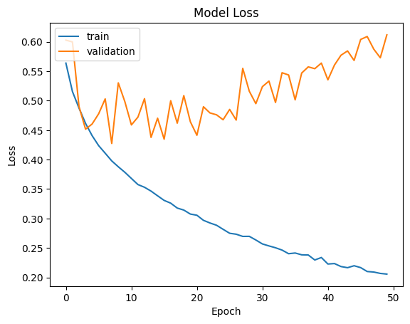

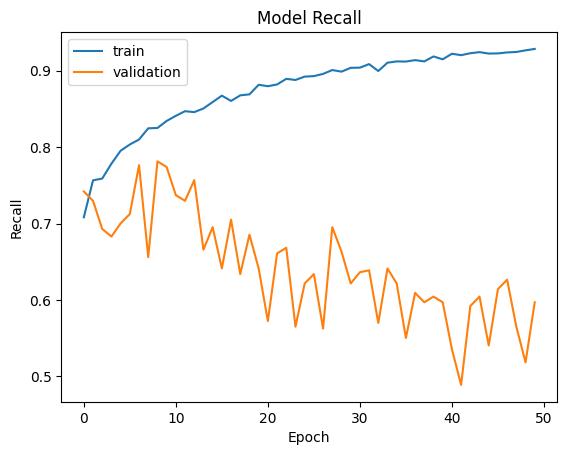

```
              precision    recall  f1-score   support

           0       0.95      0.91      0.93      4777
           1       0.92      0.95      0.93      4777

    accuracy                           0.93      9554
   macro avg       0.93      0.93      0.93      9554
weighted avg       0.93      0.93      0.93      9554

              precision    recall  f1-score   support

           0       0.89      0.83      0.86      1593
           1       0.48      0.60      0.53       407

    accuracy                           0.78      2000
   macro avg       0.68      0.71      0.69      2000
weighted avg       0.81      0.78      0.79      2000
```

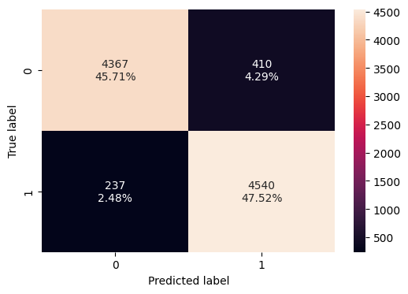

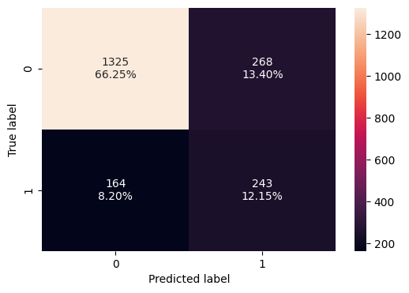

```
Model: "sequential"
_________________________________________________________________
 Layer (type)                Output Shape              Param #
=================================================================
 dense (Dense)               (None, 64)                768

 dropout (Dropout)           (None, 64)                0

 dense_1 (Dense)             (None, 32)                2080

 dropout_1 (Dropout)         (None, 32)                0

 dense_2 (Dense)             (None, 16)                528

 dropout_2 (Dropout)         (None, 16)                0

 dense_3 (Dense)             (None, 8)                 136

 dense_4 (Dense)             (None, 1)                 9

=================================================================
Total params: 3521 (13.75 KB)
Trainable params: 3521 (13.75 KB)
Non-trainable params: 0 (0.00 Byte)
_________________________________________________________________
```

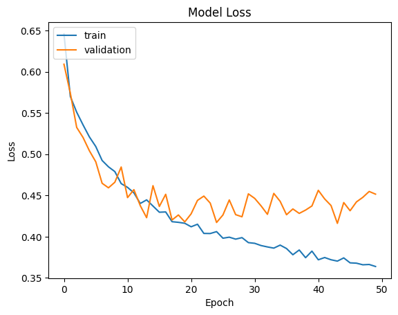

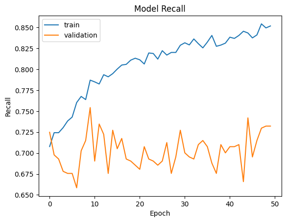

```
              precision    recall  f1-score   support

           0       0.89      0.84      0.86      4777
           1       0.85      0.90      0.87      4777

    accuracy                           0.87      9554
   macro avg       0.87      0.87      0.87      9554
weighted avg       0.87      0.87      0.87      9554

              precision    recall  f1-score   support

           0       0.92      0.81      0.86      1593
           1       0.49      0.73      0.59       407

    accuracy                           0.79      2000
   macro avg       0.71      0.77      0.72      2000
weighted avg       0.83      0.79      0.80      2000
```

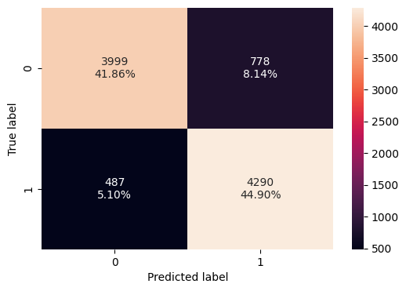

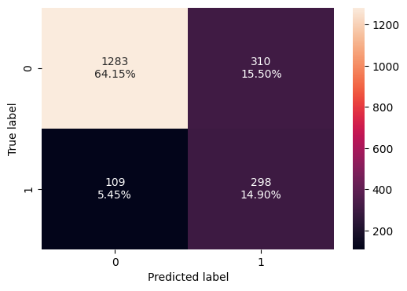

```python
# Import necessary libraries
import tensorflow as tf
from tensorflow.keras.models import Sequential
from tensorflow.keras.layers import Dense, Dropout
from tensorflow.keras.optimizers import SGD, Adam
from sklearn.metrics import recall_score, classification_report
from imblearn.over_sampling import SMOTE
import numpy as np
import matplotlib.pyplot as plt
import seaborn as sns

# Apply SMOTE to balance the dataset
sm = SMOTE(random_state=42)
X_train_smote, y_train_smote = sm.fit_resample(X_train, y_train)
print('After UpSampling, the shape of train_X: {}'.format(X_train_smote.shape))
print('After UpSampling, the shape of train_y: {} \n'.format(y_train_smote.shape))

# Building a model with SMOTE and SGD optimizer

# Clear previous models
tf.keras.backend.clear_session()
np.random.seed(2)
tf.random.set_seed(2)

# Initializing the model
model_3 = Sequential()

# Adding the input layer with 64 neurons and relu as activation function
model_3.add(Dense(64, activation='relu', input_dim=X_train_smote.shape[1]))

# Adding a hidden layer with 32 neurons and relu as activation function
model_3.add(Dense(32, activation='relu'))

# Adding another hidden layer with 16 neurons and relu as activation function
model_3.add(Dense(16, activation='relu'))

# Adding the output layer with 1 neuron and sigmoid as activation function
model_3.add(Dense(1, activation='sigmoid'))

# Using SGD as the optimizer
optimizer = SGD(0.001)

# Using recall as the metric
metric = tf.keras.metrics.Recall()

# Compiling the model with binary cross entropy as the loss function and recall as the metric
model_3.compile(loss='binary_crossentropy', optimizer=optimizer, metrics=[metric])

# Displaying the model summary
model_3.summary()

# Fitting the ANN
history_3 = model_3.fit(
    X_train_smote, y_train_smote,
    batch_size=32,  # specify the batch size
    validation_data=(X_val, y_val),
    epochs=50,  # specify the number of epochs
    verbose=1
)

# Plotting Train Loss vs Validation Loss
plt.plot(history_3.history['loss'])
plt.plot(history_3.history['val_loss'])
plt.title('Model Loss')
plt.ylabel('Loss')
plt.xlabel('Epoch')
plt.legend(['train', 'validation'], loc='upper left')
plt.show()

# Plotting Train Recall vs Validation Recall
plt.plot(history_3.history['recall'])
plt.plot(history_3.history['val_recall'])
plt.title('Model Recall')
plt.ylabel('Recall')
plt.xlabel('Epoch')
plt.legend(['train', 'validation'], loc='upper left')
plt.show()

# Predicting the results using 0.5 as the threshold
y_train_pred = model_3.predict(X_train_smote)
y_train_pred = (y_train_pred > 0.5).astype(int)

# Predicting the results on the validation set using 0.5 as the threshold
y_val_pred = model_3.predict(X_val)
y_val_pred = (y_val_pred > 0.5).astype(int)

# Storing recall scores for the model
model_name = "NN with SMOTE & SGD"
train_metric_df.loc[model_name] = recall_score(y_train_smote, y_train_pred)
valid_metric_df.loc[model_name] = recall_score(y_val, y_val_pred)

# Displaying classification report for the training set
cr = classification_report(y_train_smote, y_train_pred)
print(cr)

# Displaying classification report for the validation set
cr = classification_report(y_val, y_val_pred)
print(cr)

# Plotting confusion matrix for the training set
make_confusion_matrix(y_train_smote, y_train_pred)

# Plotting confusion matrix for the validation set
make_confusion_matrix(y_val, y_val_pred)

# Building a model with SMOTE and Adam optimizer

# Clear previous models
tf.keras.backend.clear_session()
np.random.seed(2)
tf.random.set_seed(2)

# Initializing the model
model_4 = Sequential()

# Adding the input layer with 64 neurons and relu as activation function
model_4.add(Dense(64, activation='relu', input_dim=X_train_smote.shape[1]))

# Adding a hidden layer with 32 neurons and relu as activation function
model_4.add(Dense(32, activation='relu'))

# Adding another hidden layer with 16 neurons and relu as activation function
model_4.add(Dense(16, activation='relu'))

# Adding the output layer with 1 neuron and sigmoid as activation function
model_4.add(Dense(1, activation='sigmoid'))

# Using Adam as the optimizer
optimizer = Adam()

# Using recall as the metric
metric = tf.keras.metrics.Recall()

# Compiling the model with binary cross entropy as the loss function and recall as the metric
model_4.compile(loss='binary_crossentropy', optimizer=optimizer, metrics=[metric])

# Displaying the model summary
model_4.summary()

# Fitting the ANN
history_4 = model_4.fit(
    X_train_smote, y_train_smote,
    batch_size=32,  # specify the batch size
    validation_data=(X_val, y_val),
    epochs=50,  # specify the number of epochs
    verbose=1
)

# Plotting Train Loss vs Validation Loss
plt.plot(history_4.history['loss'])
plt.plot(history_4.history['val_loss'])
plt.title('Model Loss')
plt.ylabel('Loss')
plt.xlabel('Epoch')
plt.legend(['train', 'validation'], loc='upper left')
plt.show()

# Plotting Train Recall vs Validation Recall
plt.plot(history_4.history['recall'])
plt.plot(history_4.history['val_recall'])
plt.title('Model Recall')
plt.ylabel('Recall')
plt.xlabel('Epoch')
plt.legend(['train', 'validation'], loc='upper left')
plt.show()

# Predicting the results using 0.5 as the threshold
y_train_pred = model_4.predict(X_train_smote)
y_train_pred = (y_train_pred > 0.5).astype(int)

# Predicting the results on the validation set using 0.5 as the threshold
y_val_pred = model_4.predict(X_val)
y_val_pred = (y_val_pred > 0.5).astype(int)

# Storing recall scores for the model
model_name = "NN with SMOTE & Adam"
train_metric_df.loc[model_name] = recall_score(y_train_smote, y_train_pred)
valid_metric_df.loc[model_name] = recall_score(y_val, y_val_pred)

# Displaying classification report for the training set
cr = classification_report(y_train_smote, y_train_pred)
print(cr)

# Displaying classification report for the validation set
cr = classification_report(y_val, y_val_pred)
print(cr)

# Plotting confusion matrix for the training set
make_confusion_matrix(y_train_smote, y_train_pred)

# Plotting confusion matrix for the validation set
make_confusion_matrix(y_val, y_val_pred)

# Building a model with SMOTE, Adam optimizer, and Dropout

# Clear previous models
tf.keras.backend.clear_session()
np.random.seed(2)
tf.random.set_seed(2)

# Initializing the model
model_5 = Sequential()

# Adding the input layer with 64 neurons and relu as activation function
model_5.add(Dense(64, activation='relu', input_dim=X_train_smote.shape[1]))

# Adding a dropout layer with 0.2 dropout rate
model_5.add(Dropout(0.2))

# Adding a hidden layer with 32 neurons and relu as activation function
model_5.add(Dense(32, activation='relu'))

# Adding a dropout layer with 0.2 dropout rate
model_5.add(Dropout(0.2))

# Adding another hidden layer with 16 neurons and relu as activation function
model_5.add(Dense(16, activation='relu'))

# Adding a dropout layer with 0.2 dropout rate
model_5.add(Dropout(0.2))

# Adding another hidden layer with 8 neurons and relu as activation function
model_5.add(Dense(8, activation='relu'))

# Adding the output layer with 1 neuron and sigmoid as activation function
model_5.add(Dense(1, activation='sigmoid'))

# Using Adam as the optimizer
optimizer = Adam()

# Using recall as the metric
metric = tf.keras.metrics.Recall()

# Compiling the model with binary cross entropy as the loss function and recall as the metric
model_5.compile(loss='binary_crossentropy', optimizer=optimizer, metrics=[metric])

# Displaying the model summary
model_5.summary()

# Fitting the ANN
history_5 = model_5.fit(
    X_train_smote, y_train_smote,
    batch_size=32,  # specify the batch size
    validation_data=(X_val, y_val),
    epochs=50,  # specify the number of epochs
    verbose=1
)

# Plotting Train Loss vs Validation Loss
plt.plot(history_5.history['loss'])
plt.plot(history_5.history['val_loss'])
plt.title('Model Loss')
plt.ylabel('Loss')
plt.xlabel('Epoch')
plt.legend(['train', 'validation'], loc='upper left')
plt.show()

# Plotting Train Recall vs Validation Recall
plt.plot(history_5.history['recall'])
plt.plot(history_5.history['val_recall'])
plt.title('Model Recall')
plt.ylabel('Recall')
plt.xlabel('Epoch')
plt.legend(['train', 'validation'], loc='upper left')
plt.show()

# Predicting the results using 0.5 as the threshold
y_train_pred = model_5.predict(X_train_smote)
y_train_pred = (y_train_pred > 0.5).astype(int)

# Predicting the results on the validation set using 0.5 as the threshold
y_val_pred = model_5.predict(X_val)
y_val_pred = (y_val_pred > 0.5).astype(int)

# Storing recall scores for the model
model_name = "NN with SMOTE, Adam & Dropout"
train_metric_df.loc[model_name] = recall_score(y_train_smote, y_train_pred)
valid_metric_df.loc[model_name] = recall_score(y_val, y_val_pred)

# Displaying classification report for the training set
cr = classification_report(y_train_smote, y_train_pred)
print(cr)

# Displaying classification report for the validation set
cr = classification_report(y_val, y_val_pred)
print(cr)

# Plotting confusion matrix for the training set
make_confusion_matrix(y_train_smote, y_train_pred)

# Plotting confusion matrix for the validation set
make_confusion_matrix(y_val, y_val_pred)
```

## Model Performance Comparison and Final Model Selection

```
[[0]
 [0]
 [0]
 ...
 [1]
 [0]
 [0]]
              precision    recall  f1-score   support

           0       0.92      0.80      0.86      1593
           1       0.48      0.72      0.58       407

    accuracy                           0.79      2000
   macro avg       0.70      0.76      0.72      2000
weighted avg       0.83      0.79      0.80      2000
```

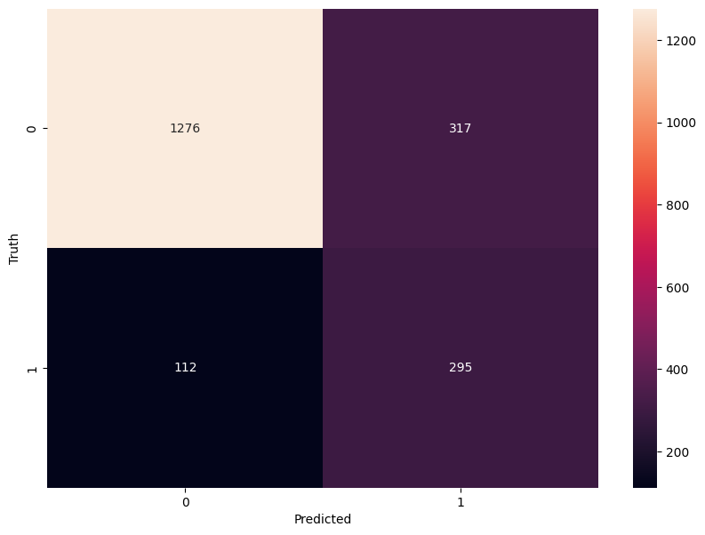

```python
X_test = X_test.astype(float)

# Predicting on the test set with the best model
y_test_pred = model_5.predict(X_test)
y_test_pred = (y_test_pred > 0.5).astype(int)
print(y_test_pred)

# Print classification report for the test set
cr = classification_report(y_test, y_test_pred)
print(cr)

# Calculating the confusion matrix for the test set
def make_confusion_matrix(y_true, y_pred):
    from sklearn.metrics import confusion_matrix
    import seaborn as sns
    import matplotlib.pyplot as plt

    cm = confusion_matrix(y_true, y_pred)
    plt.figure(figsize=(10, 7))
    sns.heatmap(cm, annot=True, fmt='d')
    plt.xlabel('Predicted')
    plt.ylabel('Truth')
    plt.show()

make_confusion_matrix(y_test, y_test_pred)
```

## Actionable Insights and Business Recommendations

Business Recommendations Improve Customer Retention Strategies:

The recall for class 1 (churned customers) is 0.72, indicating that the model is relatively good at identifying customers who are likely to leave. Focus on these predicted churners by implementing targeted retention strategies. Personalized offers, loyalty programs, and enhanced customer service can be used to retain high-risk customers. Focus on Precision for Churned Customers:

The precision for class 1 (churned customers) is 0.48, meaning that when the model predicts a customer will churn, it is correct 48% of the time. While this is reasonable, there is room for improvement. Conduct a deeper analysis to understand false positives (customers predicted to churn but don't). This could involve reviewing customer feedback, transaction history, and engagement metrics. Leverage Non-Churned Customer Insights:

With a high precision (0.92) and recall (0.80) for non-churned customers, identify what is working well for retaining these customers. Look into their usage patterns, satisfaction surveys, and feedback. Use these insights to reinforce and replicate positive experiences across the customer base. Segmentation-Based Strategies:

Segment customers based on their predicted churn risk and tailor interventions accordingly. High-risk segments can be offered more aggressive retention incentives, while low-risk segments can be targeted with loyalty programs to further increase satisfaction and reduce future churn risks. Geography and Age Group Targeting:

Utilize the geographic and age group insights from the data analysis to create specific campaigns. For instance, if certain geographies or age groups have higher churn rates, design customized offers or communication strategies for these segments. Regional managers can be tasked with addressing specific needs and concerns in high-churn areas.

Power Ahead